# Lab 7A: Deep Learning (Easy)

### 1. Explore the Data

1. Set the working directory

```r
setwd("C:/Workshop/Data")
```

2. Load the MNIST data set

```r
mnist <- read.csv('mnist.csv')
```

3. Inspect the number of rows

```r
nrow(mnist)
```

```
## [1] 70000
```

4. Inspect the number of columns

```r
ncol(mnist)
```

```
## [1] 785
```

5. Inspect the first few rows and columns

```r
mnist[c(1:6), c(1:6)]
```

```
##   Label Pixel0 Pixel1 Pixel2 Pixel3 Pixel4
## 1     3      0      0      0      0      0
## 2     5      0      0      0      0      0
## 3     0      0      0      0      0      0
## 4     4      0      0      0      0      0
## 5     1      0      0      0      0      0
## 6     9      0      0      0      0      0
```

6. Create a function to display an image

```r
display_image <- function(values) {

  first_image <- matrix(
    data = as.numeric(values),
    nrow = 28,
    ncol = 28)

  image(
    x = 1:28,
    y = 1:28,
    z = first_image[,28:1],
    col = gray((0:255) / 255))
}
```

7. Inspect the first few images

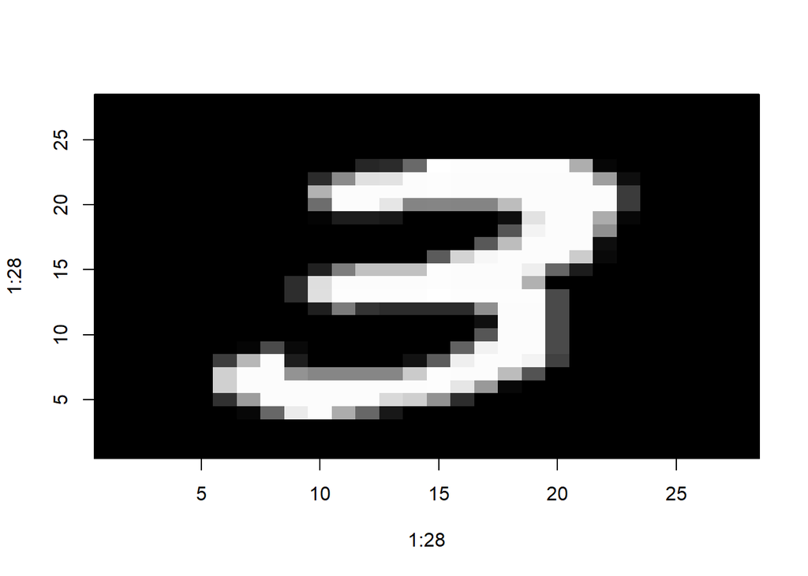

```r
display_image(mnist[1, -1])
```

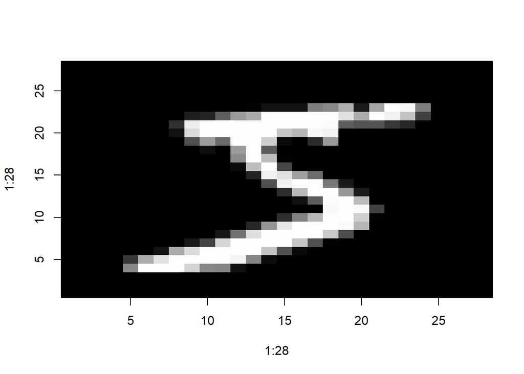

```r
display_image(mnist[2, -1])
```

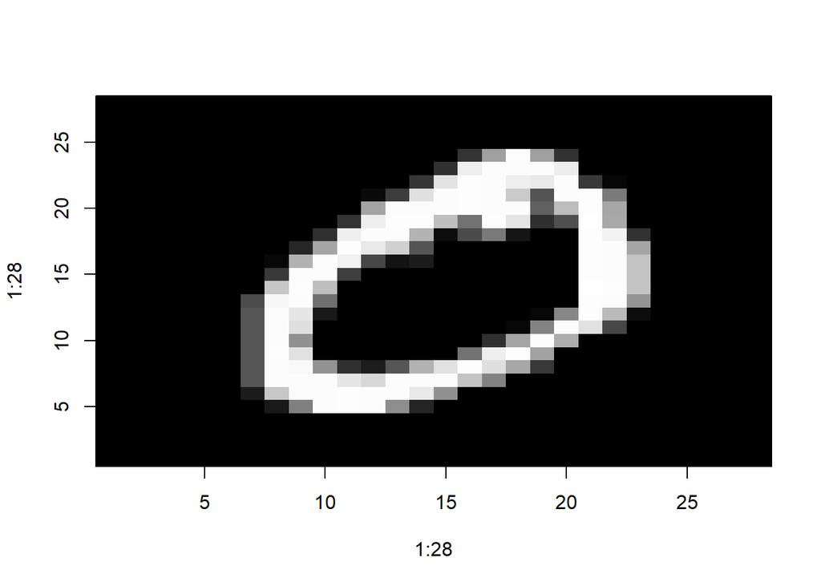

```r
display_image(mnist[3, -1])
```

8. Scale the feature from [0-256] to [0-1]

```r
mnist[, -1] <- mnist[, -1] / 255
```

### 2. Split the Data into Training and Test Set

1. Set the seed to make randomness reproducable

```r
set.seed(42)
```

2. Load the caret package

```r
library(caret)
```

3. Randomly sample 80% of the row indexes

```r
indexes <- createDataPartition(
  y = mnist$Label,
  p = 0.80,
  list = FALSE)
```

4. Create a training set from indexes

```r
train <- mnist[indexes, ]
```

5. Create a test set from the remaining indexes

```r
test <- mnist[-indexes, ]
```

### 3. Prepare the Data for Training and Testing

1. Convert the training set to a matix

```r
train <- data.matrix(train)
```

2. Convert the test set to matix

```r
test <- data.matrix(test)
```

3. Assign the training features

```r
train.X <- train[, -1]
```

4. Assign the training labels

```r
train.y <- train[, 1]
```

5. Transpose the training features

```r
train.X <- t(train.X)
```

6. Assign the test features

```r
test.X <- test[,-1]
```

7. Assign the test labels

```r
test.y <- test[,1]
```

8. Transpose the test features

```r
test.X <- t(test.X)
```

### 4. Create a Fully-connected Deep Neural Network

(input) -> (128-relu) -> (64-relu) -> (10-softmax)

1. Load the MXNet package

```r
library(mxnet)
```

2. Create the input layer

```r
data <- mx.symbol.Variable("data")
```

3. Create the 1st fully-connected hidden layer

```r
fc1 <- mx.symbol.FullyConnected(
  data = data,
  name = "fc1",
  num_hidden = 128)
```

4. Create the 1st activation function (relu)

```r
act1 <- mx.symbol.Activation(
  data = fc1,
  name = "relu1",
  act_type = "relu")
```

5. Create the 2nd fully-connected hidden layer

```r
fc2 <- mx.symbol.FullyConnected(
  data = act1,
  name = "fc2",
  num_hidden = 64)
```

6. Create the 2nd activation function (relu)

```r
act2 <- mx.symbol.Activation(
  data = fc2,
  name = "relu2",
  act_type = "relu")
```

7. Create the output layer

```r
fc3 <- mx.symbol.FullyConnected(
  data = act2,
  name = "fc3",
  num_hidden = 10)
```

8. Create the output activation function (softmax)

```r
softmax <- mx.symbol.SoftmaxOutput(
  data = fc3,
  name = "sm")
```

9. Set the MXNet random seed

```r
mx.set.seed(0)
```

10. Train the model  
    *Note: This could take several minutes*

```r
model <- mx.model.FeedForward.create(
  symbol = softmax,
  X = train.X,
  y = train.y,
  ctx = mx.cpu(),
  num.round = 10,
  array.batch.size = 100,
  array.layout = "colmajor",
  learning.rate = 0.07,
  momentum = 0.9,
  eval.metric = mx.metric.accuracy,
  initializer = mx.init.uniform(0.07),
  epoch.end.callback = mx.callback.log.train.metric(100))
```

```
## Start training with 1 devices
```

```
## [1] Train-accuracy=0.881321428571429
```

```
## [2] Train-accuracy=0.964367201426029
```

```
## [3] Train-accuracy=0.974866310160433
```

```
## [4] Train-accuracy=0.980713012477724
```

```
## [5] Train-accuracy=0.98532976827095
```

```
## [6] Train-accuracy=0.987272727272733
```

```
## [7] Train-accuracy=0.988894830659542
```

```
## [8] Train-accuracy=0.989411764705887
```

```
## [9] Train-accuracy=0.990320855614978
```

```
## [10] Train-accuracy=0.992156862745102
```

### 5. Make Predictions with a Deep Neural Network

1. Make predictions

```r
predictions <- predict(
  model = model,
  X = test.X,
  array.layout = "colmajor")
```

2. Inspect the predictions (10 rows and 5 columns)

```r
predictions[c(1:10), c(1:5)]
```

```
##               [,1]         [,2]         [,3]         [,4]         [,5]
##  [1,] 1.217150e-11 2.954578e-10 2.039231e-15 1.671076e-19 4.528356e-17
##  [2,] 2.226623e-09 1.774382e-08 9.999988e-01 2.455169e-18 9.999992e-01
##  [3,] 1.051749e-06 9.997466e-01 2.775412e-10 2.404473e-15 1.370465e-12
##  [4,] 1.237605e-11 2.299937e-05 6.921732e-12 1.980869e-24 7.804410e-14
##  [5,] 9.999783e-01 5.768558e-12 2.340842e-07 1.000000e+00 2.899438e-08
##  [6,] 3.147552e-11 5.995425e-08 4.599089e-12 1.780616e-19 1.259315e-13
##  [7,] 1.465700e-11 3.368522e-11 4.108656e-08 3.977188e-19 8.399476e-11
##  [8,] 4.631866e-08 1.676053e-08 5.419324e-07 1.992443e-15 7.950326e-07
##  [9,] 1.429726e-10 2.303039e-04 3.094940e-07 1.246647e-18 1.398742e-09
## [10,] 2.056944e-05 2.451040e-09 6.384679e-12 1.666695e-13 3.587880e-13
```

3. Transpose the predictions

```r
predictions <- t(predictions)
```

4. Inspect the predictions (5 rows and 10 columns)

```r
predictions[c(1:5), c(1:10)]
```

```
##              [,1]         [,2]         [,3]         [,4]         [,5]
## [1,] 1.217150e-11 2.226623e-09 1.051749e-06 1.237605e-11 9.999783e-01
## [2,] 2.954578e-10 1.774382e-08 9.997466e-01 2.299937e-05 5.768558e-12
## [3,] 2.039231e-15 9.999988e-01 2.775412e-10 6.921732e-12 2.340842e-07
## [4,] 1.671076e-19 2.455169e-18 2.404473e-15 1.980869e-24 1.000000e+00
## [5,] 4.528356e-17 9.999992e-01 1.370465e-12 7.804410e-14 2.899438e-08
##              [,6]         [,7]         [,8]         [,9]        [,10]
## [1,] 3.147552e-11 1.465700e-11 4.631866e-08 1.429726e-10 2.056944e-05
## [2,] 5.995425e-08 3.368522e-11 1.676053e-08 2.303039e-04 2.451040e-09
## [3,] 4.599089e-12 4.108656e-08 5.419324e-07 3.094940e-07 6.384679e-12
## [4,] 1.780616e-19 3.977188e-19 1.992443e-15 1.246647e-18 1.666695e-13
## [5,] 1.259315e-13 8.399476e-11 7.950326e-07 1.398742e-09 3.587880e-13
```

5. Convert the probabilites into classes

```r
predictions <- max.col(predictions) - 1
```

```r
head(predictions)
```

```
## [1] 4 2 1 4 1 8
```

7. Inspect the correct answers from test data set

```r
head(test.y)
```

```
##  4  7  8 10 41 47
##  4  2  1  4  1  8
```

8. Inspect the first few test images

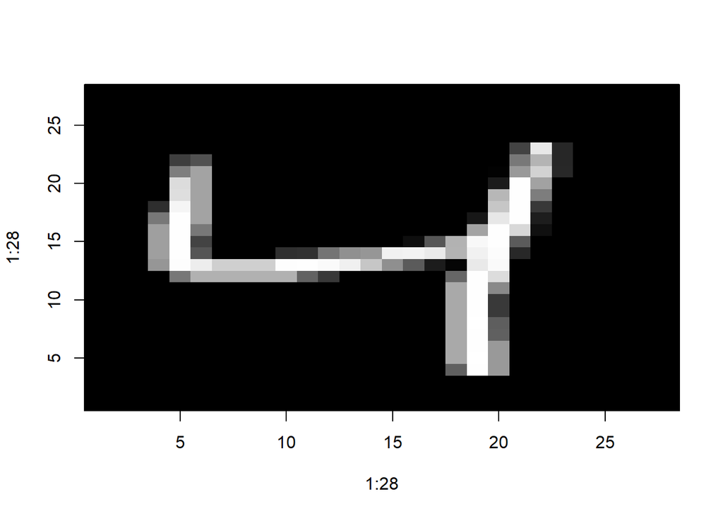

```r
display_image(test.X[, 1])
```

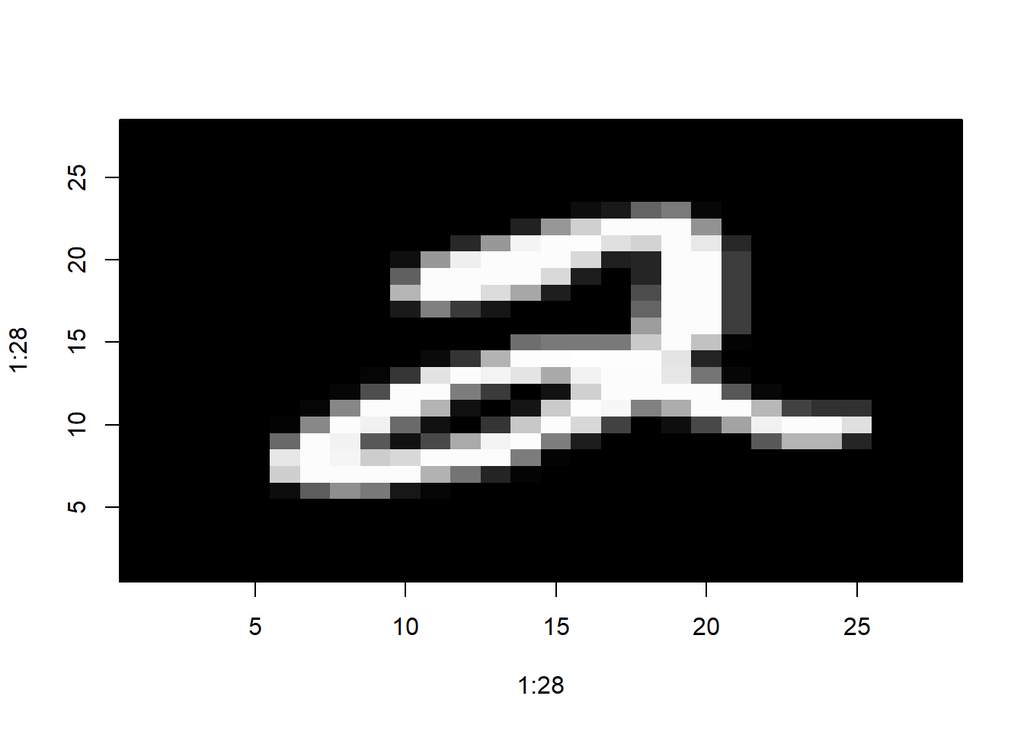

```r
display_image(test.X[, 2])
```

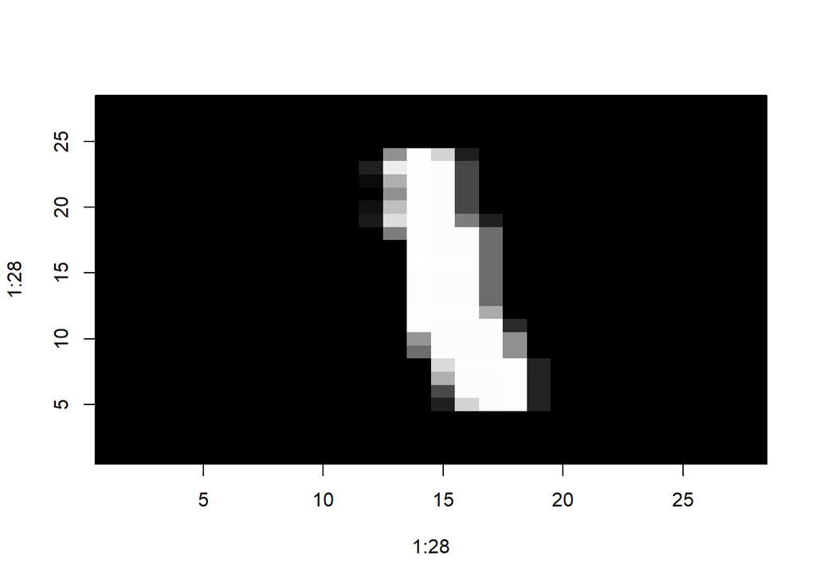

```r
display_image(test.X[, 3])
```

9. Evaluate the prediction accuracy

```r
confusionMatrix(
  data = predictions,
  reference = test.y)
```

```
## Confusion Matrix and Statistics
##
##           Reference
## Prediction    0    1    2    3    4    5    6    7    8    9
##          0 1354    0    9    4    0    7    5    0    3    3
##          1    0 1570    6    3    0    3    0    3    9    3
##          2    1    4 1343   10    1    0    0    5    5    1
##          3    1    0    5 1382    0   15    0    2    8    3
##          4    3    4    4    0 1337    4    5    4    3   13
##          5    0    0    1    4    0 1207    7    0    5    2
##          6    7    0    1    0    1   10 1321    0    4    0
##          7    2    2   12   17    1    0    2 1459    1   12
##          8    4    1   15   13    1   10    4    3 1350    2
##          9    4    0    1    6   13    9    1   10    5 1324
##
## Overall Statistics
##
##                Accuracy : 0.9749
##                  95% CI : (0.9721, 0.9774)
##     No Information Rate : 0.1129
##     P-Value [Acc > NIR] : < 2.2e-16
##
##                   Kappa : 0.972
##  Mcnemar's Test P-Value : NA
##
## Statistics by Class:
##
##                      Class: 0 Class: 1 Class: 2 Class: 3 Class: 4 Class: 5
## Sensitivity           0.98401   0.9930  0.96135  0.96039  0.98744  0.95415
## Specificity           0.99754   0.9978  0.99786  0.99729  0.99684  0.99851
## Pos Pred Value        0.97762   0.9831  0.98029  0.97599  0.97095  0.98450
## Neg Pred Value        0.99826   0.9991  0.99572  0.99547  0.99865  0.99546
## Prevalence            0.09829   0.1129  0.09979  0.10279  0.09672  0.09036
## Detection Rate        0.09672   0.1122  0.09594  0.09872  0.09551  0.08622
## Detection Prevalence  0.09894   0.1141  0.09786  0.10115  0.09836  0.08758
## Balanced Accuracy     0.99078   0.9954  0.97960  0.97884  0.99214  0.97633
##                      Class: 6 Class: 7 Class: 8 Class: 9
## Sensitivity           0.98216   0.9818  0.96913  0.97139
## Specificity           0.99818   0.9961  0.99580  0.99612
## Pos Pred Value        0.98289   0.9675  0.96222  0.96431
## Neg Pred Value        0.99810   0.9978  0.99659  0.99691
## Prevalence            0.09608   0.1062  0.09951  0.09736
## Detection Rate        0.09436   0.1042  0.09644  0.09458
## Detection Prevalence  0.09601   0.1077  0.10022  0.09808
## Balanced Accuracy     0.99017   0.9890  0.98246  0.98375
```